# Lab 9

# Chapter 12: Analysis of Variance

Analysis of Variance presents methods for testing equality of three or more population means.

## 12-1: One-Way ANOVA

One-Way Analysis of Variance is a method for testing the equality of three or more population means by analyzing the sample variances. We test the following hypotheses:

**Null and Alternative Hypotheses:**

- $H_0: \mu_1 = \mu_2 = \mu_3 = \cdots = \mu_k$
- $H_a:$ At least one pair of means are not the same.

To perform the test, the raw data must be organized in the right format. For example, if we have the data in the form:

| Column1 | Column2 | Column3 | Column4 |
| --- | --- | --- | --- |
| $a_1$ | $b_1$ | $c_1$ | $d_1$ |
| $a_2$ | $b_2$ | $c_2$ | $d_2$ |
| $a_3$ | $b_3$ | $c_3$ | $d_3$ |
| $a_4$ | $b_4$ | $c_4$ | $d_4$ |
| $a_5$ | $b_5$ | $c_5$ | $d_5$ |

Then we write the following R code:

Column1 <- c(a_1,a_2,a_3,a_4,a_5)

Column2 <- c(b_1,b_2,b_3,b_4,b_5)

Column3 <- c(c_1,c_2,c_3,c_4,c_5)

Column4 <- c(d_1,d_2,d_3,d_4,d_5)

Data1 <- c(Column1, Column2, Column3, Column4)

Data <- data.frame(Data1, Column_names)

Please note that the last line of the code above is only for the display of the data. It is totally optional, and can be left out without affecting the results.

We can obtain a boxplot of the data to get a visual picture of how the populations compare.

Next, we perform Levene’s Test for homogeneity of variances by first installing the “car”package:

install.packages (“car”)

and typing the following code:

LeveneTest(Data1, Column_names)

A nonsignificant result is required before we can proceed to perform the ANOVA test. We preform the ANOVA test using the following R command:

model <- aov(Data1 ~ Column_names)

To obtain the output, we type the following command:

summary(model)

If the output shows significance, we can perform Tukey’s HSD Test by typing the following command:

TukeyHSD(model)

**Example 1** Use the head injury criterion (HIC) measurements listed in the table below and use a significance level of 0.05 to test the claim that the four samples come from populations with means that are all equal.

| Small | Midsize | Large | SUV |
| --- | --- | --- | --- |
| 253 | 117 | 249 | 121 |
| 143 | 121 | 90 | 112 |
| 124 | 204 | 178 | 261 |
| 301 | 195 | 114 | 145 |
| 422 | 186 | 183 | 198 |
| 324 | 178 | 87 | 193 |
| 258 | 157 | 180 | 193 |
| 271 | 203 | 103 | 111 |
| 467 | 132 | 154 | 276 |
| 298 | 212 | 129 | 156 |
| 315 | 229 | 266 | 213 |
| 304 | 235 | 338 | 143 |

**Solution**

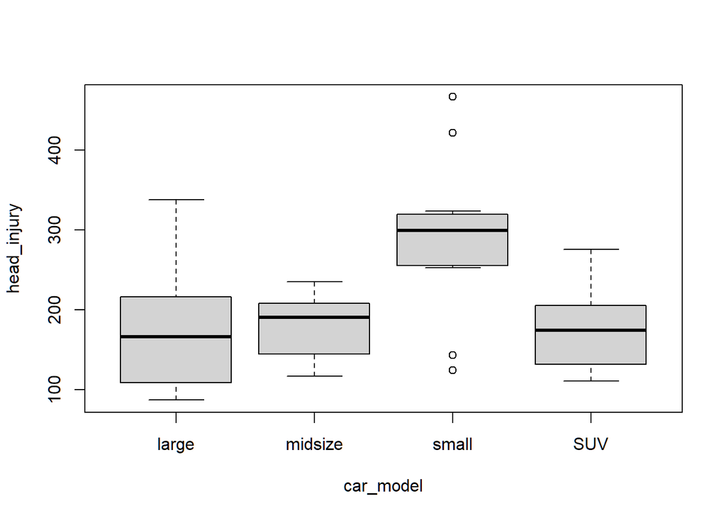

```r
small <- c(253, 143, 124, 301, 422, 324, 258, 271, 467, 298, 315, 304)
midsize <- c(117, 121, 204, 195, 186, 178, 157, 203, 132, 212, 229, 235)
large <- c(249, 90, 178, 114, 183, 87, 180, 103, 154, 129, 266, 338)
SUV  <- c(121, 112, 261, 145, 198, 193, 193, 111, 276, 156, 213, 143)
head_injury <- c(small, midsize, large, SUV)
car_model <- c(rep("small", 12), rep("midsize", 12), rep("large", 12), rep("SUV", 12))
HIC <- data.frame(head_injury, car_model)
head_injury <- c(small, midsize, large, SUV)
car_model <- c(rep("small", 12), rep("midsize", 12), rep("large", 12), rep("SUV", 12))

boxplot(head_injury ~ car_model)
```

```r
library(car)
leveneTest(head_injury, car_model)
```

```
## Levene's Test for Homogeneity of Variance (center = median)
##       Df F value Pr(>F)
## group  3  1.2742 0.2949
##       44
```

```r
ANOVA1 <- aov(head_injury ~ car_model)

summary(ANOVA1)
```

```
##             Df Sum Sq Mean Sq F value   Pr(>F)
## car_model    3 115887   38629   7.685 0.000309 ***
## Residuals   44 221159    5026
## ---
## Signif. codes:  0 '***' 0.001 '**' 0.01 '*' 0.05 '.' 0.1 ' ' 1
```

```r
TukeyHSD(ANOVA1)
```

```
##   Tukey multiple comparisons of means
##     95% family-wise confidence level
##
## Fit: aov(formula = head_injury ~ car_model)
##
## $car_model
##                      diff        lwr       upr     p adj
## midsize-large    8.166667  -69.11249  85.44582 0.9920514
## small-large    117.416667   40.13751 194.69582 0.0011124
## SUV-large        4.250000  -73.02915  81.52915 0.9988535
## small-midsize  109.250000   31.97085 186.52915 0.0025935
## SUV-midsize     -3.916667  -81.19582  73.36249 0.9991015
## SUV-small     -113.166667 -190.44582 -35.88751 0.0017343
```

## 12-2: Two-Way ANOVA

We perform the two-way ANOVA test by typing the following command

model <- aov(variable_name ~ row_name + column_name + row_name * column_name)

As in section 12-1, we can obtain the output by typing the following command:

summary(model)

**Solution**

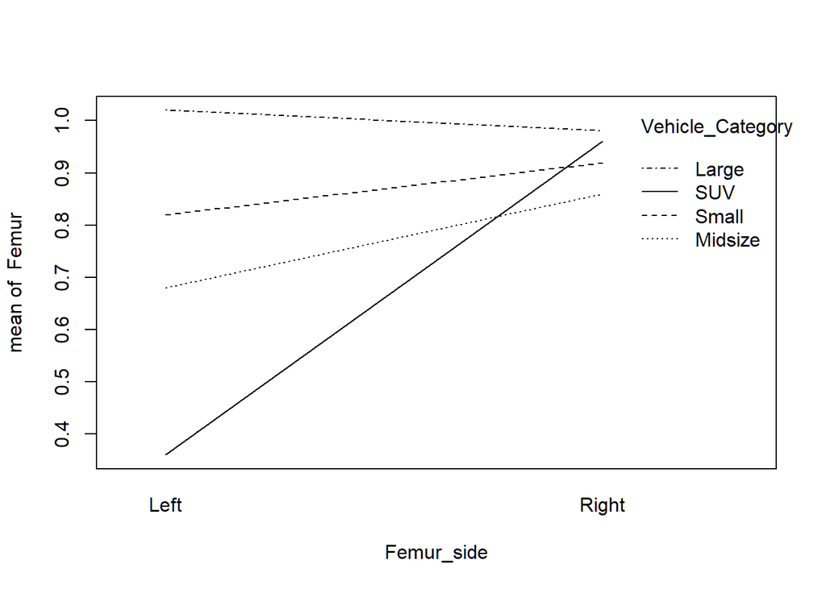

```r
Femur_left <- c(1.6, 1.4, 0.5, 0.2, 0.4, 0.4, 0.7, 1.1, 0.7, 0.5, 0.6, 1.8, 0.3, 1.3, 1.1, 0.4, 0.4, 0.6, 0.2, 0.2)
Femur_right <- c(2.8, 1.0, 0.3, 0.3, 0.2, 0.6, 0.8, 1.3, 0.5, 1.1, 1.5, 1.7, 0.2, 0.6, 0.9, 0.7, 0.7, 3.0, 0.2, 0.2)
Femur <- c(Femur_left, Femur_right)
Femur_side <- c(rep("Left", 20), rep("Right", 20))
Vehicle_Category <- c(rep("Small", 5), rep("Midsize", 5), rep("Large", 5), rep("SUV", 5),rep("Small", 5), rep("Midsize", 5), rep("Large", 5), rep("SUV", 5))
Crash_Test_Force <- data.frame(Femur, Femur_side, Vehicle_Category)

interaction.plot(Femur_side, Vehicle_Category, Femur)
```

```r
ANOVA1 <- aov(Femur ~ Femur_side + Vehicle_Category + Femur_side * Vehicle_Category)

summary(ANOVA1)
```

```
##                             Df Sum Sq Mean Sq F value Pr(>F)
## Femur_side                   1  0.441  0.4410   0.900  0.350
## Vehicle_Category             3  0.629  0.2097   0.428  0.734
## Femur_side:Vehicle_Category  3  0.569  0.1897   0.387  0.763
## Residuals                   32 15.676  0.4899
```